# NYPD Shooting Data

2023-04-28

# NYPD Shooting Incident Data (Historic)

This data looks at the shootings that occurred in New York City between 2006 and 2021 (inclusive). The data includes the following information:

- INCIDENT_KEY
- OCCUR_DATE
- OCCUR_TIME
- BORO
- PRECINCT
- JURISDICTION_CODE
- LOCATION_DESC
- STATISTICAL_MURDER_FLAG
- PERP_AGE_GROUP
- PERP_SEX
- PERP_RACE
- VIC_AGE_GROUP
- VIC_SEX
- VIC_RACE
- X_COORD_CD
- Y_COORD_CD
- Latitude
- Longitude
- Lon_Lat

## Data Source

To download csv file: https://data.cityofnewyork.us/api/views/833y-fsy8/rows.csv?accessType=DOWNLOAD

Source location (for reference and other data formats): https://catalog.data.gov/dataset/nypd-shooting-incident-data-historic

Note the file name used in this markdown is: NYPD_Shooting_Incident_Data__Historic_.csv

To recreate this analysis, make sure you use the same file name (noting the extra underscore between “Data” and “Historic” as well as the one at the end).

```r
library(tidyverse)
library(knitr)
url = "https://raw.githubusercontent.com/nsxydis/boulder_dsf/main/NYPD_shooting_incident/NYPD_Shooting_Incident_Data__Historic_.csv"
df = read_csv(url)
```

## Clean up the data

For this analysis we’ll be looking at the age of shooting victims and the date that incidents occurred. This will be used for further analysis on the trends of victim age over time.

As part of the tidying process, we’ll remove “UNKNOWN” entries for the VIC_AGE_GROUP column and transform the data to a factor. Additionally, we’ll convert the OCCUR_DATE column to a date variable named Date. Furthermore we’ll add a character column to specify which age category a age group is in.

We will add a column named Year which is just the year that a murder took place.

We will add an integer “Victim” that will be used to count the victims.

```r
# Convert the occur date to a date data type named Date
df = df %>% mutate(Date = mdy(OCCUR_DATE))

# Add season to the data
df$Season = cut(as.numeric(format(df$Date, "%m")),
                     c(0, 2, 5, 8, 11, 12),
                     labels = c("Winter", "Spring", "Summer", "Fall", "Winter"))

# PERP DATA FRAME
# Remove Unknown/blank and other error perp age entries
perp = df %>% filter(PERP_AGE_GROUP != "UNKNOWN")
perp = perp %>% filter(PERP_AGE_GROUP != "1020")
perp = perp %>% filter(PERP_AGE_GROUP != "940")
perp = perp %>% filter(PERP_AGE_GROUP != "224")
perp = perp %>% filter(PERP_AGE_GROUP != "")
# Convert perp ages to a factor
perp = perp %>% mutate(Perp_Age_Group = as.factor(PERP_AGE_GROUP))
# Add the text name of ages
age_groups = c("Teen", "Young Adult", "Adult", "Senior Adult", "Elderly")
# Add an age group's name
perp$Age_Category = ifelse(perp$PERP_AGE_GROUP == "<18", "Teen",
                  ifelse(perp$PERP_AGE_GROUP == "18-24", "Young Adult",
                  ifelse(perp$PERP_AGE_GROUP == "25-44", "Adult",
                  ifelse(perp$PERP_AGE_GROUP == "45-64", "Senior Adult",
                  ifelse(perp$PERP_AGE_GROUP == "65+", "Elderly", "Error")))))

# VICTIM DATA FRAME
# Remove Unknown victim age entries
df = df %>% filter(VIC_AGE_GROUP != "UNKNOWN")
# Convert victim ages to a factor
df = df %>% mutate(Victim_Age_Group = as.factor(VIC_AGE_GROUP))
# Add the text name of victim ages
age_groups = c("Teen", "Young Adult", "Adult", "Senior Adult", "Elderly")
# Add an age group's name
df$Age_Category = ifelse(df$VIC_AGE_GROUP == "<18", "Teen",
                  ifelse(df$VIC_AGE_GROUP == "18-24", "Young Adult",
                  ifelse(df$VIC_AGE_GROUP == "25-44", "Adult",
                  ifelse(df$VIC_AGE_GROUP == "45-64", "Senior Adult",
                  ifelse(df$VIC_AGE_GROUP == "65+", "Elderly", "Error")))))

# Only keep the necessary columns
keep = c("INCIDENT_KEY", "Date", "OCCUR_TIME", "Victim_Age_Group", "Age_Category", "Season")
filtered = df[keep]

# Add a column for the year (as a number)
filtered = filtered %>% mutate(Year = year(Date))

# Add a column to count victims by
filtered = filtered %>% mutate(Victim = 1)
```

## Victim Age Breakdown

We will first look at the age groups of victims. See below for a table showing the number of victims in each age group across all of the data.

The age groups are classified as follows:  
Teen: Less than 18 years old  
Young Adult: Between 18 and 24 years old  
Adult: Between 25 and 44 years old  
Senior Adult: Between 45 and 64 years old  
Elderly: 65 or more years old

Note that unknown victim ages are excluded from this summary.

```r
# Find the date range of the data
startDate = min(filtered$Date)
endDate = max(filtered$Date)
string = paste0("This data covers the following date range: ", startDate,
             " to ", endDate)
print(noquote(string))
```

```
## [1] This data covers the following date range: 2006-01-01 to 2021-12-31
```

```r
ages = filtered %>%
  group_by(Victim_Age_Group, Age_Category) %>%
  summarize(Victims = sum(Victim))

kable(ages)
```

| Victim_Age_Group | Age_Category | Victims |
| --- | --- | --- |
| <18 | Teen | 2681 |
| 18-24 | Young Adult | 9604 |
| 25-44 | Adult | 11386 |
| 45-64 | Senior Adult | 1698 |
| 65+ | Elderly | 167 |

### Initial takeaways

From the first breakdown of the data we can see that a majority of shooting victims are in the Young Adult and Adult category. It’s interesting to note that Young Adult ages cover a 7 year span (18 to 24) whereas Adults cover a 20 year span (25-44) but the number of victims in either category are relatively close. It would be interesting to pair this data against the age demographics for New York City to see if the proportions of each age group are similar.

## Perp Age Breakdown

```r
# Make a data frame just with the relevant columns
keep = c("INCIDENT_KEY", "Date", "OCCUR_TIME", "Perp_Age_Group", "Age_Category", "Season")
perp_filtered = perp[keep]
# Add a column to count victims by
perp_filtered = perp_filtered %>% mutate(Perpetrator = 1)

# Plot the table
perp_ages = perp_filtered %>%
  group_by(Perp_Age_Group, Age_Category) %>%
  summarize(Perpetrators = sum(Perpetrator))

kable(perp_ages)
```

| Perp_Age_Group | Age_Category | Perpetrators |
| --- | --- | --- |
| <18 | Teen | 1463 |
| 18-24 | Young Adult | 5844 |
| 25-44 | Adult | 5202 |
| 45-64 | Senior Adult | 535 |
| 65+ | Elderly | 57 |

## Look at the age relationship between perpetrators and victims

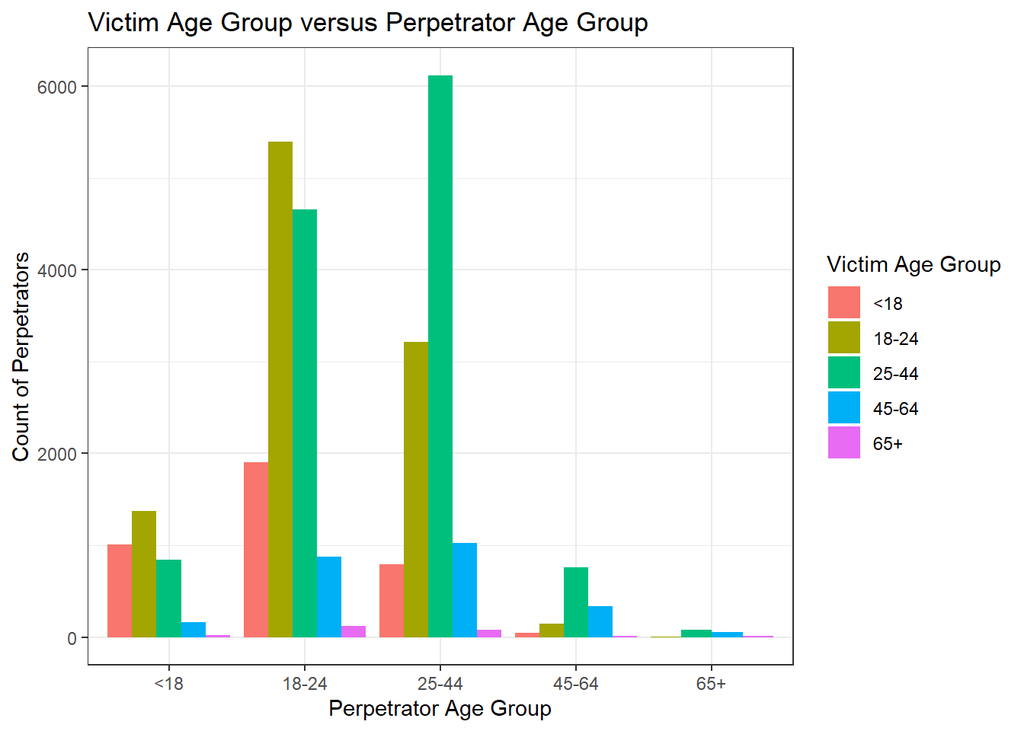

```r
merged_df = merge(filtered, perp_filtered, by = "INCIDENT_KEY")
library(dplyr)
library(ggplot2)

perp_count = merged_df %>%
  group_by(Perp_Age_Group, Victim_Age_Group) %>%
  summarise(Count = n())
# Create the grouped bar chart
ggplot(perp_count, aes(x = Perp_Age_Group, y = Count, fill = Victim_Age_Group)) +
  geom_bar(stat = "identity", position = position_dodge()) +
  labs(x = "Perpetrator Age Group", y = "Count of Perpetrators",
       title = "Victim Age Group versus Perpetrator Age Group") +
  scale_fill_discrete(name = "Victim Age Group") +
  theme_bw()
```

## Graphical Analysis

Next we’ll look at a few graphical representations of the data.  
1) Count of victims separated by Age Category over time in years  
2) Time of day a shooting occurred

### Shooting Victims Age Category Over Time

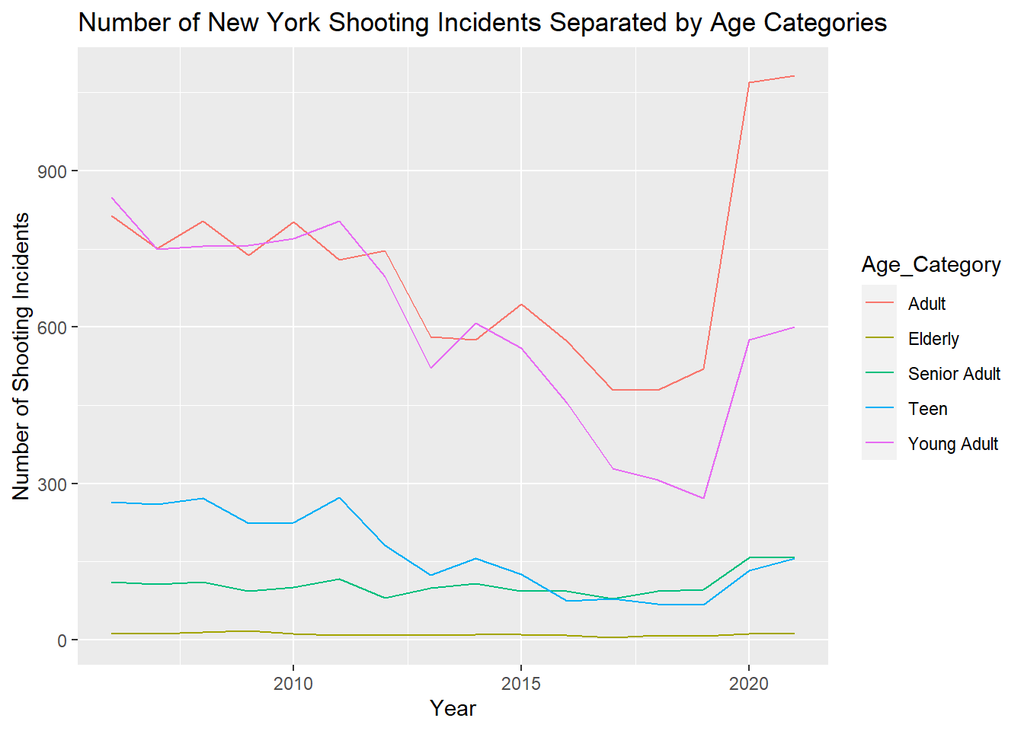

```r
years = filtered %>%
  group_by(Year, Victim_Age_Group, Age_Category) %>%
  summarize(Victims = sum(Victim))

p = ggplot(years, aes(x = Year, y = Victims)) +
  ggtitle("Number of New York Shooting Incidents Separated by Age Categories") +
  xlab("Year") +
  ylab("Number of Shooting Incidents")

p + geom_line(aes(color = Age_Category))
```

When looking at the age groups of victims over time we see some changes in trends. Data collection began in 2006 and we see that the number of Young Adult victims has diverged from Adult starting around 2014.

More strikingly, we see that across all groups the number of victims increased in 2020 and persisted into 2021. This could be another point of reference to investigate further. It is possible this could be related to COVID-19 when people were forced into lock downs. New York City was hit particularly hard during the start of the pandemic. To make claims like this we would need further data such as police reports that define the relationship between shooters and victims.

### Time of Day Shootings Occured

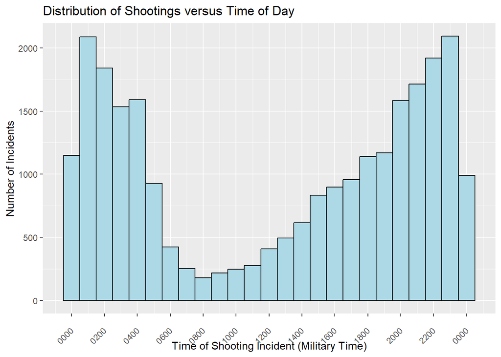

```r
# Give the OCCUR_TIME a fake date to allow plotting
filtered$OCCUR_TIME <- as.POSIXct(paste("1970-01-01", format(filtered$OCCUR_TIME, "%H:%M:%S")))

# Make our plot and adjust the labels
p = ggplot(filtered, aes(x = OCCUR_TIME)) +
  ggtitle("Distribution of Shootings versus Time of Day") +
  xlab("Time of Shooting Incident (Military Time)") +
  ylab("Number of Incidents")
p + geom_histogram(binwidth = 60*60, fill = "lightblue", color = "black") +
                    scale_x_datetime(date_labels = "%H%M", date_breaks = "2 hour") +
                    theme(axis.text.x = element_text(angle = 45, vjust = 0.5, hjust=1))
```

This chart takes a look at all of the data and focuses on what time shootings happen. The histogram makes a bi-modal distribution with peaks around 1AM (0100) and 11PM (2300). One of the easy takeaways would be that most shootings don’t take place during working hours. This is probably because a majority of people are working at their jobs and not out and about. Another indication could be that shootings are less likely to take place while there’s daylight. A further analysis could break down the data into seasons and the approximate sunrise and sunset times to make groups such as: Before Sunrise, Dawn, Daylight, Dusk, After Sunset.

### Season Shootings Occurred

```r
seasons = filtered %>%
  group_by(Year, Season) %>%
  summarize(Victims = sum(Victim))
```

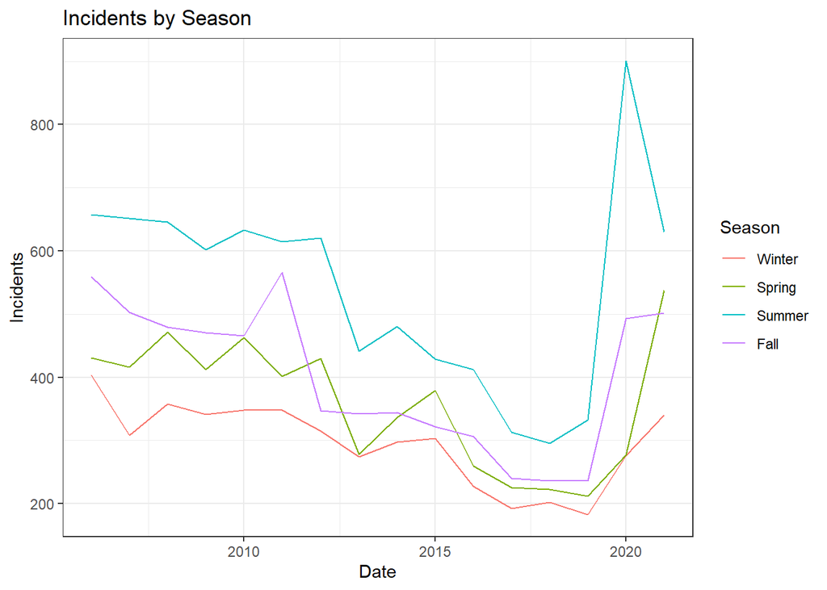

```r
ggplot(seasons, aes(x = Year, y = Victims, group = Season, color = Season)) +
  geom_line() +
  labs(x = "Date", y = "Incidents", title = "Incidents by Season") +
  scale_color_discrete(name = "Season", labels = c("Winter", "Spring", "Summer", "Fall")) +
  theme_bw()
```

## Bias and mitigation

There are many sources of bias when looking at data and this data is no different. For starters, it’s collected by the police department so we are relying on their integrity and diligence in reporting the data correctly.

Another potential bias comes from the analyzer of the data. It wouldn’t be hard to gloss over the data and start making claims that were ethically dubious. An example could be looking at the age category of perpetrators and making claims that one age group is inherently more dangerous than another.

As an attempt to mitigate biases, I tried to present the data as it was and instead of making sudden conclusions, offer suggestions of other data that could be looked at or analyzed. Though in an effort to reduce bias there is a somewhat ironic introduction of bias as well. Being too tentative when looking at data could shield valid conclusions from the data. So, that is something to keep in mind as well.

## Conclusions

This dataset has a lot of information. But with all good information comes questions that need more information. I think further analysis could offer some interesting ideas. Maybe by looking at more data like shooting occurrences and time of day after incorporating seasonal sunrise and sunset times we would see a trend that less shootings occur during well lit hours. A possible experiment could follow by increasing illumination during dark hours in more dangerous locations to see if it has an impact on the number of shootings or just crime in general.